# RMarkdown_Demo_1

Erik Bolch

# Example R Markdown Script

### Adapted from: Tidy data and efficient manipulation coding club tutorial

##### January 18th 2017

##### Sandra Angers-Blondin (s.angers-blondin@ed.ac.uk)

##### 24/Jan/2017

Install and load the relevant packages

Changed tidyr to tidyverse

```r
library(dplyr) # an excellent data manipulation package
library(tidyverse) # a package to format your data
library(pander) #to create pretty tables
```

Set your working directory to the folder where you have downloaded the datasets

Commented out because not recommended for Rmd files

```r
#setwd("./data/CC-3-DataManip-master")
```

Import data

Germination file didn’t exist, changed to dragons which is included.

```r
elongation <- read_csv("./data/CC-3-DataManip-master/EmpetrumElongation.csv") # stem elongation measurements on Empetrum
dragons <- read_csv("./data/CC-3-DataManip-master/dragons.csv") # dragons subjected to spices
```

Tidying the data and Putting the data into long format using gather()

```r
elongation_long <- gather(elongation, Year, Length, c(X2007, X2008, X2009, X2010, X2011, X2012))
  #gather() works like this: data, key, value, columns to gather. Here we want the lengths (value) to be gathered by year (key). Note that you are completely making up the names of the second and third arguments, unlike most functions in R.
head(elongation_long)
```

```
## # A tibble: 6 x 4
##    Zone Indiv Year  Length
##   <dbl> <dbl> <chr>  <dbl>
## 1     2   373 X2007    5.1
## 2     2   379 X2007    8.1
## 3     2   383 X2007    9.3
## 4     2   389 X2007   15
## 5     2   390 X2007    3.5
## 6     2   395 X2007    6.1
```

Investigating the data Create a boxplot of `elongation_long’ to visualise elongation for each year.

This set of boxplots can be added to your R Markdown document by putting the code in a code chunk

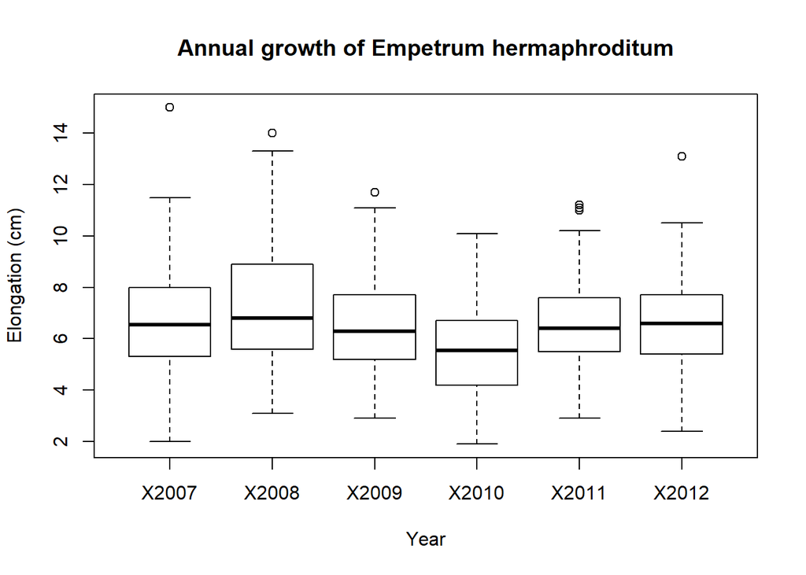

```r
boxplot(Length ~ Year,
        data = elongation_long,
        xlab = "Year",
        ylab = "Elongation (cm)",
        main = "Annual growth of Empetrum hermaphroditum")
```

Use filter() to keep only the rows of ‘dragon’ for species ‘hungarian_horntail’

```r
dragon.hh <- filter(dragons, species == 'hungarian_horntail')
```

Let’s have a look at the distribution of dragons species exposed to spices This histogram can be added to your R Markdown document by simply putting the code in a code chunk Try adding some plain text to your R markdown document to explain the histogram

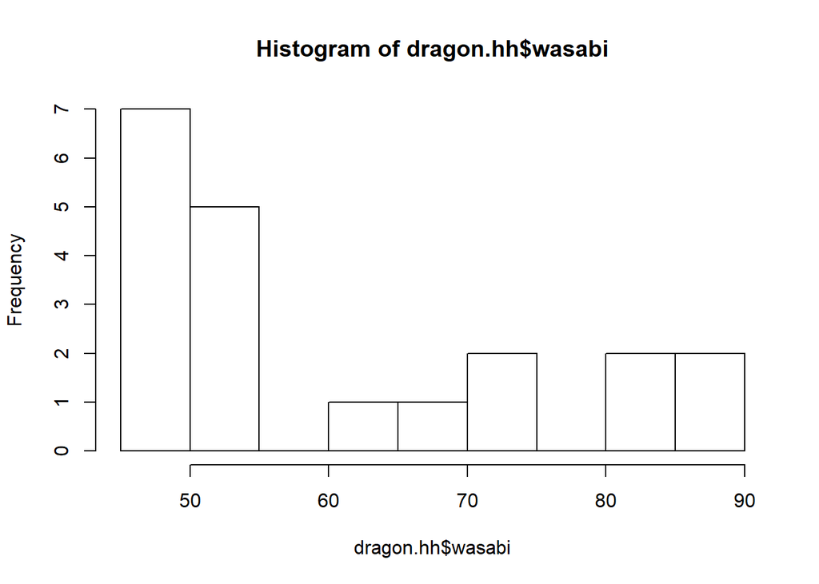

```r
hist(dragon.hh$wasabi, breaks = 8)
```

Use mutate() to create a new column of the dragon percentage using the total number total and the number of dragons exposed to jalapeno out of total spice exposure

```r
dragon_j_percent <- mutate(dragons, Percent_Jalapeno = jalapeno / (tabasco+jalapeno+wasabi+paprika) * 100)
head(dragon_j_percent)
```

```
## # A tibble: 6 x 7
##   dragon.ID species        tabasco jalapeno wasabi paprika Percent_Jalapeno
##       <dbl> <chr>            <dbl>    <dbl>  <dbl>   <dbl>            <dbl>
## 1         1 hungarian_hor~     124      100     45      25             34.0
## 2         4 hungarian_hor~     156      110     47      30             32.1
## 3         7 hungarian_hor~     147       90     55      25             28.4
## 4        10 hungarian_hor~     138      136     47      23             39.5
## 5        13 hungarian_hor~     154      124     53      23             35.0
## 6        16 hungarian_hor~     110       92     48      32             32.6
```

```r
dragon_summ <- dragon_j_percent %>%
  group_by(species) %>%
  summarise("Mean jalapeno exposure per" = mean(jalapeno), "Max jalapeno exposure per" = max(jalapeno), "Min jalapeno exposure" = min(jalapeno))
```

Make a table of ‘dragon_summ’ in your R markdown document using pander(), the instructions can be found in the tutorial

```r
pander(dragon_summ)
```

Table continues below

| species | Mean jalapeno exposure per | Max jalapeno exposure per |
| --- | --- | --- |
| hungarian_horntail | 119.2 | 141 |
| swedish_shortsnout | 152.4 | 195 |
| welsh_green | 121.1 | 152 |

| Min jalapeno exposure |
| --- |
| 87 |
| 113 |
| 98 |